# Extreme Subgroup Effects Under a Uniform Treatment Effect: ACTG 175, Continuous Outcome

# 4 Part III — Subgroup Catalog (50 total)

```r
subgroups <- list(
  list(id = "flag_itt == 1",              name = "All Patients",        grp = "ITT"),
  # Clinical binaries (both levels each)
  list(id = "hemo == 1",    name = "Hemophilia",        grp = "Clinical"),
  list(id = "hemo == 0",    name = "No hemophilia",     grp = "Clinical"),
  list(id = "homo == 1",    name = "MSM",               grp = "Clinical"),
  list(id = "homo == 0",    name = "Non-MSM",           grp = "Clinical"),
  list(id = "drugs == 1",   name = "IVDU history",      grp = "Clinical"),
  list(id = "drugs == 0",   name = "No IVDU",           grp = "Clinical"),
  list(id = "race == 1",    name = "Non-white",         grp = "Clinical"),
  list(id = "race == 0",    name = "White",             grp = "Clinical"),
  list(id = "gender == 0",  name = "Female",            grp = "Clinical"),
  list(id = "gender == 1",  name = "Male",              grp = "Clinical"),
  list(id = "symptom == 1", name = "Symptomatic",       grp = "Clinical"),
  list(id = "symptom == 0", name = "Asymptomatic",      grp = "Clinical"),
  # Continuous splits (panel-frozen cuts)
  list(id = "age <= age_med",   name = "Age (young)",     grp = "Continuous"),
  list(id = "age > age_med",    name = "Age (older)",     grp = "Continuous"),
  list(id = "age <= 35",        name = "Age <= 35",       grp = "Continuous"),
  list(id = "age > 35",         name = "Age > 35",        grp = "Continuous"),
  list(id = "wtkg <= wtkg_med", name = "Weight (low)",    grp = "Continuous"),
  list(id = "wtkg > wtkg_med",  name = "Weight (high)",   grp = "Continuous"),
  list(id = "karnof < 100",  name = "Karnofsky < 100", grp = "Continuous"),
  list(id = "karnof == 100", name = "Karnofsky 100",   grp = "Continuous"),
  list(id = "cd40 <= cd40_med", name = "CD4 low",         grp = "Continuous"),
  list(id = "cd40 > cd40_med",  name = "CD4 high",        grp = "Continuous"),
  list(id = "cd40 <= cd40_q1",  name = "CD4 lowest quartile", grp = "Continuous"),
  list(id = "cd80 <= cd80_med", name = "CD8 low",         grp = "Continuous"),
  list(id = "cd80 > cd80_med",  name = "CD8 high",        grp = "Continuous"),
  list(id = "preanti <= pre_med", name = "Short prior ART", grp = "Continuous"),
  list(id = "preanti > pre_med",  name = "Long prior ART",  grp = "Continuous"),
  # Two-way interactions
  list(id = "symptom == 1 & cd40 <= cd40_med", name = "Sympt/CD4-low",   grp = "Interaction"),
  list(id = "symptom == 1 & cd40 > cd40_med",  name = "Sympt/CD4-high",  grp = "Interaction"),
  list(id = "symptom == 0 & cd40 <= cd40_med", name = "Asympt/CD4-low",  grp = "Interaction"),
  list(id = "age <= age_med & cd40 <= cd40_med", name = "Young/CD4-low", grp = "Interaction"),
  list(id = "age > age_med & cd40 <= cd40_med",  name = "Older/CD4-low", grp = "Interaction"),
  list(id = "age > age_med & symptom == 1",      name = "Older/Sympt",   grp = "Interaction"),
  list(id = "gender == 0 & drugs == 1",   name = "Female/IVDU",     grp = "Interaction"),
  list(id = "gender == 0 & race == 1",    name = "Female/Non-white",grp = "Interaction"),
  list(id = "karnof < 100 & cd40 <= cd40_med", name = "Karn<100/CD4-low", grp = "Interaction"),
  list(id = "hemo == 1 & age <= age_med", name = "Hemo/Young",      grp = "Interaction"),
  list(id = "drugs == 1 & symptom == 1",  name = "IVDU/Sympt",      grp = "Interaction"),
  list(id = "race == 1 & cd40 <= cd40_med", name = "Non-white/CD4-low", grp = "Interaction"),
  list(id = "wtkg <= wtkg_med & karnof < 100", name = "LowWt/Karn<100", grp = "Interaction"),
  list(id = "preanti > pre_med & cd40 <= cd40_med", name = "LongART/CD4-low", grp = "Interaction"),
  # Three-way
  list(id = "symptom == 1 & cd40 <= cd40_med & age > age_med",
       name = "Sympt/CD4-low/Older", grp = "3-way"),
  list(id = "gender == 0 & drugs == 1 & cd40 <= cd40_med",
       name = "Fem/IVDU/CD4-low", grp = "3-way"),
  list(id = "race == 1 & symptom == 1 & cd40 <= cd40_med",
       name = "NW/Sympt/CD4-low", grp = "3-way"),
  list(id = "hemo == 1 & cd40 <= cd40_med & karnof < 100",
       name = "Hemo/CD4-low/Karn<100", grp = "3-way")
,
  # Random benchmarks: columns injected per replicate by benchmark_spec();
  # the catalog must NAME them to analyze them (the gbsg twin's pattern)
  list(id = "random60 == 1", name = "random60", grp = "Random"),
  list(id = "random40 == 1", name = "random40", grp = "Random"),
  list(id = "random20 == 1", name = "random20", grp = "Random"),
  list(id = "random15 == 1", name = "random15", grp = "Random")
)
```

# 5 Part IV — Simulation and Results

```r
n_cores_total <- future::availableCores()
n_workers     <- max(1L, ceiling(0.90 * n_cores_total))
future::plan(future::multisession, workers = n_workers)
sims_uniform <- run_subgroup_sims(
  dgm        = dgm_uniform,
  subgroups  = subgroups,
  n_sims     = n_sims_uniform,
  baseline   = "fixed",                 # frozen observed panel, N = 1083
  benchmarks = benchmark_spec(),        # random15 in 20 in 40 in 60
  cutpoints  = cuts,
  workers    = NULL,                    # reuse the plan above
  seed_base  = seed_base,
  hr_true    = md_true)
future::plan(future::sequential)
```

```r
saveRDS(list(sim_hrs = sims_uniform$sim_hrs, sim_ubs = sims_uniform$sim_ubs,
             sim_ns = sims_uniform$sim_ns, subgroups = subgroups,
             effect = sims_uniform$effect, md_true = md_true,
             design = design_label, n_sims = n_sims_uniform,
             seed_dgm = seed_dgm, seed_base = seed_base,
             created = Sys.time()),
        file.path(payload_dir, payload_file))
```

```r
# UB(MD) tails c(10, 20): round decline values bracketing ~1x / ~2x the
# ITT-scale SE (7.889 / 15.78) on the frozen panel -- the identity-scale
# analogue of the twin's UB(HR) >= 2 / >= 3.
S <- summary(sims_uniform, ub_thresholds = c(10, 20))
print(S)
```

```
<subgroup_sims_summary>  design: glm | n_sims: 10,000 | subgroups: 50 | true MD: -26.98

              Subgroup    N #(% converged) Pr(MD<lo) Pr(MD>0)    mMD
          All Patients 1083   10000 (100%)         -       0% -27.15
            Hemophilia   92   10000 (100%)         -      16% -26.42
         No hemophilia  991   10000 (100%)         -       0% -27.19
                   MSM  725   10000 (100%)         -     0.2%  -27.1
               Non-MSM  358   10000 (100%)         -     2.4% -27.12
          IVDU history  142   10000 (100%)         -    10.9% -27.24
               No IVDU  941   10000 (100%)         -     0.1% -27.12
             Non-white  311   10000 (100%)         -     3.1% -27.26
                 White  772   10000 (100%)         -     0.2% -27.12
                Female  179   10000 (100%)         -     8.1% -27.14
                  Male  904   10000 (100%)         -     0.1% -27.06
           Symptomatic  192   10000 (100%)         -     7.2% -27.16
          Asymptomatic  891   10000 (100%)         -     0.1% -27.06
           Age (young)  554   10000 (100%)         -     0.7% -27.06
           Age (older)  529   10000 (100%)         -     0.8% -27.16
             Age <= 35  603   10000 (100%)         -     0.6% -27.16
              Age > 35  480   10000 (100%)         -     1.2%  -27.1
          Weight (low)  545   10000 (100%)         -     0.6% -27.15
         Weight (high)  538   10000 (100%)         -     0.7% -27.13
       Karnofsky < 100  457   10000 (100%)         -     1.3% -26.98
         Karnofsky 100  626   10000 (100%)         -     0.4% -27.18
               CD4 low  542   10000 (100%)         -     0.6% -27.22
              CD4 high  541   10000 (100%)         -     0.6% -26.98
   CD4 lowest quartile  271   10000 (100%)         -       4% -26.97
               CD8 low  542   10000 (100%)         -     0.7%  -26.9
              CD8 high  541   10000 (100%)         -     0.7% -27.31
       Short prior ART  542   10000 (100%)         -     0.7%  -27.1
        Long prior ART  541   10000 (100%)         -     0.8% -27.02
         Sympt/CD4-low  112   10000 (100%)         -    12.7% -27.33
        Sympt/CD4-high   80   10000 (100%)         -    17.3% -27.45
        Asympt/CD4-low  430   10000 (100%)         -     1.3% -27.02
         Young/CD4-low  276   10000 (100%)         -     3.8% -27.16
         Older/CD4-low  266   10000 (100%)         -       4% -27.27
           Older/Sympt  107   10000 (100%)         -    13.5% -27.22
           Female/IVDU   38   10000 (100%)         -    26.5%  -27.3
      Female/Non-white  100   10000 (100%)         -    14.1% -27.27
      Karn<100/CD4-low  220   10000 (100%)         -     5.5% -27.19
```

[output cut: 49 more lines]

```
          69.6%          54.5%   23.13
          41.1%          20.8%    6.22
          78.2%          68.1%   34.41
          87.9%          83.7%   71.84
          54.2%          35.9%    12.1
          42.2%          22.2%    6.46
          28.4%          10.5%    1.52
            78%          67.9%   35.35
          89.8%          86.7%   93.95
          87.7%          83.9%   74.51
          90.2%          87.5%  103.52
          80.1%          71.2%   39.18
            85%          78.9%   55.22
          89.6%          86.5%   88.73
          90.7%          88.1%  107.72
```

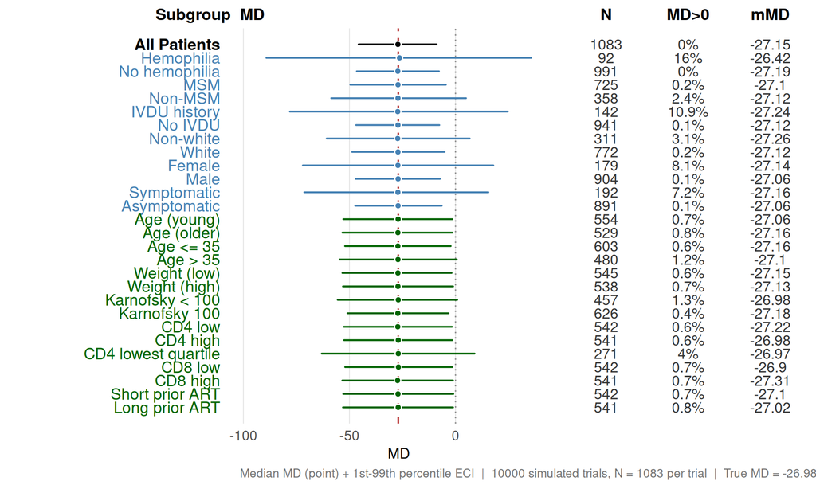

```r
plot(S, metric = "hr", panel = "single")
```

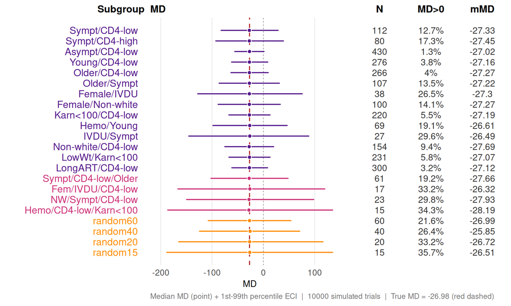

```r
plot(S, metric = "hr", panel = "combo")
```

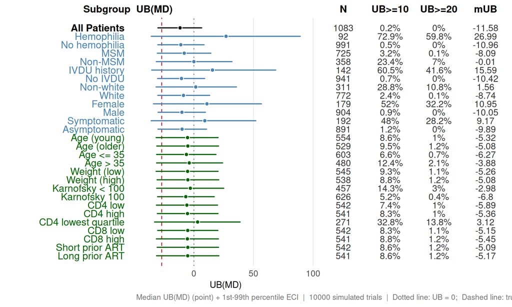

```r
plot(S, metric = "ub", panel = "single")
```

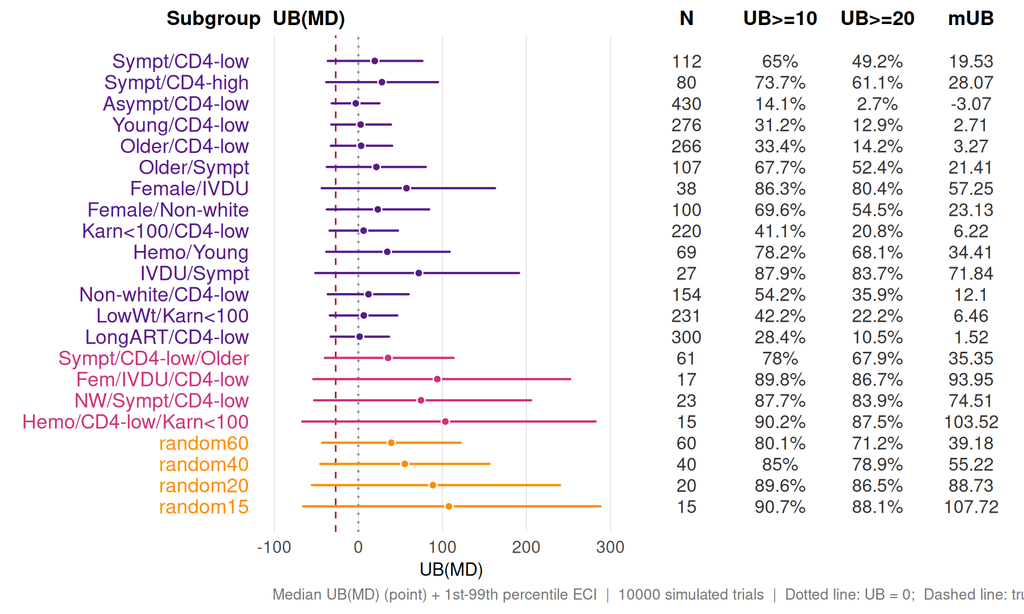

```r
plot(S, metric = "ub", panel = "combo")
```

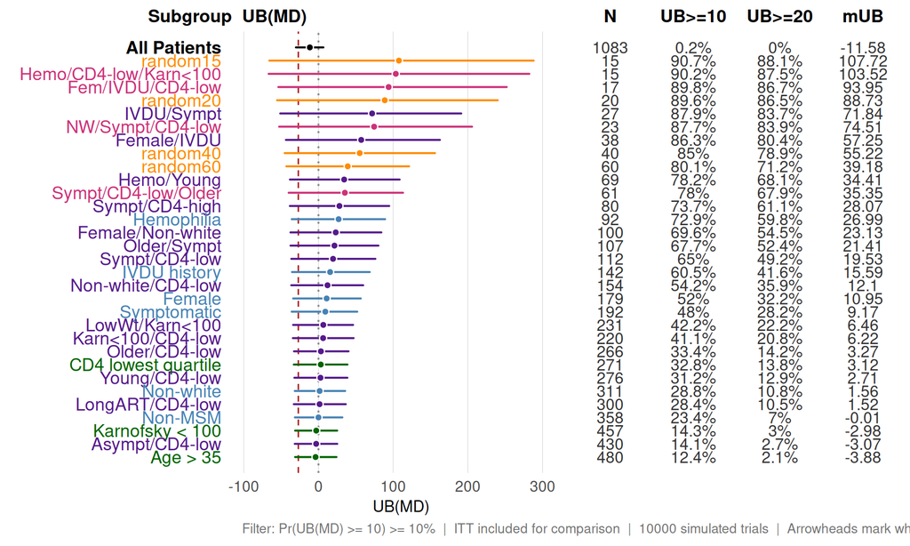

```r
plot(S, metric = "ub", panel = "highrisk")
```

# 6 Findings

Across 10,000 fixed-panel replicates the uniform truth is recovered in every subgroup: the median MD sits at approximately -27 CD4 cells of decline regardless of N (from -27.2 at the full panel of 1,083 to -26.5 at random15’s fifteen patients). All dispersion is sample-size: the median UB(MD) climbs monotonically from -11.6 (ITT; 99th percentile 6.6, so the full panel essentially never even reaches the null) to +107.7 at random15, whose 99th percentile is 288 – more than ten times the true benefit in the harmful direction – with Pr(UB >= 20) rising from 0.000 to 0.881 along the same curve.

Clinical labels confer no protection. Hemophilia (N = 92) shows Pr(UB >= 20) = 0.598 and Female/Non-white (N = 100) 0.545, bracketed by the meaningless random60 (0.713); IVDU/Symptomatic (N = 27) at 0.837 sits between random20 (0.865) and random40 (0.789); the three-way cells at N = 15-23 are statistically indistinguishable from random15. A reviewer seeing UB(MD) of +20, +50, or even +100 CD4 cells in a two-digit subgroup is looking at the expected behavior of a uniformly beneficial treatment – the calibration these benchmarks exist to provide before any single forest plot is read.

# 7 Appendix: New-Results Workflow

Re-render with `-P n_sims:...` for a different scale; payloads load in the design-comparison pattern established by the gbsg twins (`readRDS(file.path(payload_dir, payload_file))` recovers the raw matrices, subgroup list, and metadata).